# Midterm Momentum

Can street mobilization be an electoral barometer?

Lowell Monis[^1]

March 31, 2025

Midterm elections in the U.S. are often a referendum on the party in power, with the out-party typically gaining seats. But what happens when protest movements—spontaneous, ideologically charged, and highly visible—disrupt historical trends? The 2018 and 2022 midterms, followed by the 2020 and 2024 presidential cycles, offer a fascinating case study. While polls and economic indicators dominate electoral forecasting, protest activity provides a real-time pulse of the national mood, sometimes foreshadowing unexpected outcomes.

This analysis leverages protest data from the Crowd Counting Consortium (2017–2024) (Ulfelder (2025a), Ulfelder (2025b)) to argue that the valence (left/right lean) and focus of mass mobilization can override traditional midterm dynamics. Notably, while left-leaning protests have consistently outnumbered right-leaning ones since 2017, shifts in right-wing mobilization may signal electoral momentum for Republicans.

# The Blue Wave

In 2018, the Democratic Party flipped 41 House seats, fueled by anti-Trump sentiment and a surge in progressive activism that led to the launch of the “Squad” into Congress and resulted in major primary losses for “old-guard” Democrats, including House Democrats chair Joe Crowley (Goldmacher and Martin (2018)). Protest data from that year reveals a diffuse but energetic left-wing mobilization: demonstrations targeted immigration (family separations), healthcare (ACA repeal attempts), and by a large margin, gun reform. Figure 1 shows the distribution of protest issues in 2018.

#### 2018 Protest Issues

[interactive chart not shown]

Figure 1

Meanwhile, right-leaning protests were lean in number in 2018 as seen in Figure 2—a stark contrast to future years.

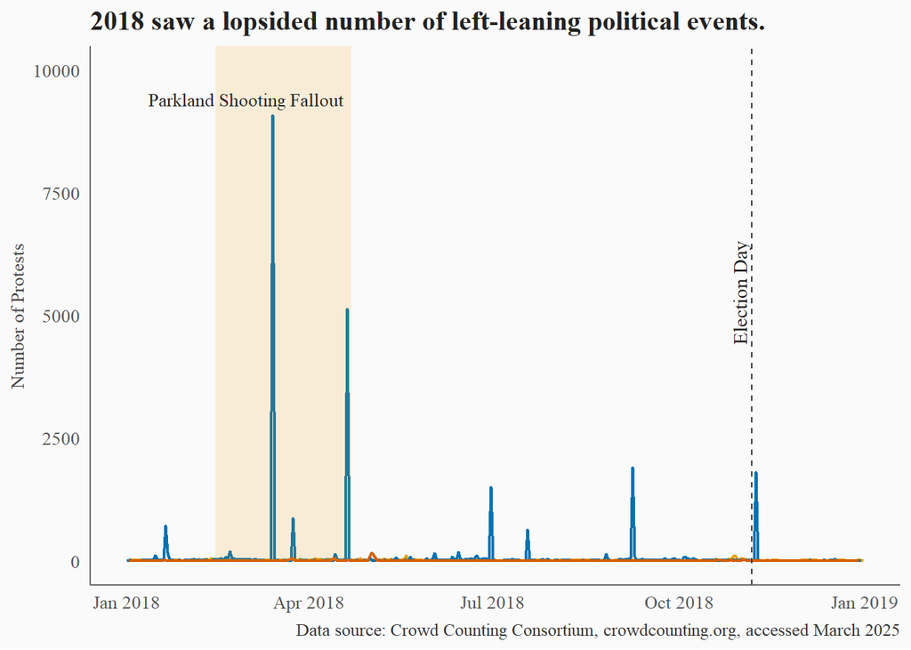

Figure 2

# The Backlash That Broke A Red Wave

Historical trends pointed to a Republican landslide in 2022: Biden’s approval ratings languished, inflation soared, and midterms typically punish the incumbent party (Prokop (2022)). Yet the GOP’s expected “red wave” collapsed, resulting in a razor-thin House majority and Democratic Senate gains. Protest data tells the story.

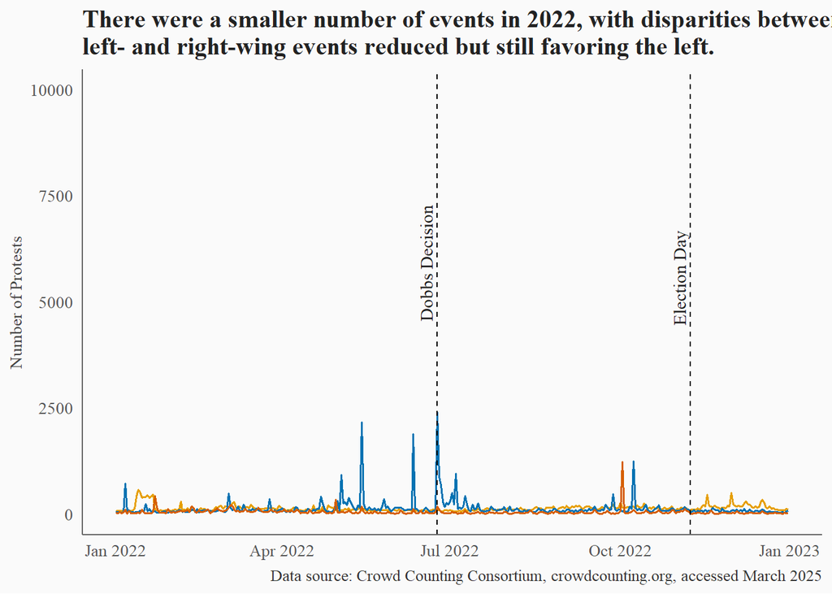

Figure 3

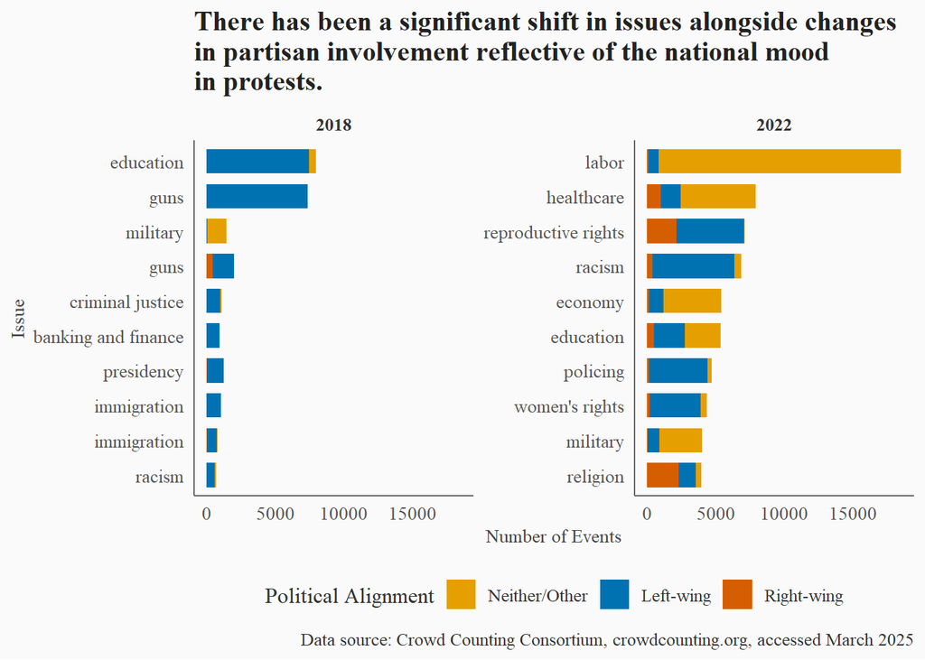

Figure 4

#### 2022 Protest Issues

[interactive chart not shown]

Figure 5

# What about presidential years?

Extending the analysis to presidential cycles reveals nuances:

In 2020, the COVID-19 pandemic suppressed protest activity overall, but left-wing movements (e.g., racial justice protests after George Floyd’s killing) still dominated. The sole major right-leaning mobilization were anti-lockdown rallies. As we know, Democrats swept the election with the largest number of votes ever cast for a single candidate.

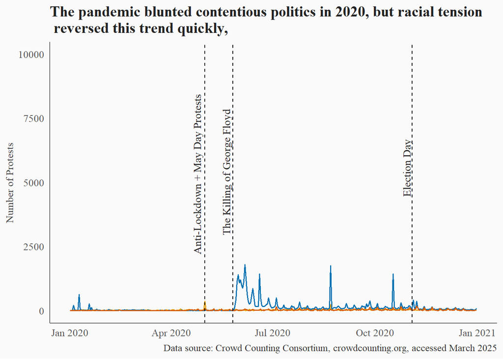

Figure 6

#### 2020 Protest Issues

[interactive chart not shown]

Figure 7

[figure not shown]

Figure 8

#### 2024 Protest Issues

[interactive chart not shown]

Figure 9

# Limitations and Caveats

Two key caveats temper these insights. The data covers only 2017–2024, a period skewed toward Democratic overperformance in 3 of 4 federal elections. The data also includes multiple outlier election cycles that were unprecedented and rare in American history, with the COVID-19 pandemic raging on in 2020, and a presumptive nominee dropping out mid-cycle in 2024. Additionally, single-issue movements (e.g., abortion) may mobilize voters more effectively than diffuse grievances.

# Why Protests Might Outperform Polls

Polls often lag behind real-time sentiment, but protests capture intensity—a critical factor in voter turnout. Left-wing protests were consistently more numerous, but electoral impact depends on issue salience. On the other hand, right-Wing surges, even if smaller, may foreshadow GOP momentum. For analysts, tracking protest volume, valence, and issue focus could complement traditional metrics. This lays the groundwork for interesting insights, and with more historical data, we can determine the legitimacy of this theory.

# References

Goldmacher, Shane, and Jonathan Martin. 2018. “Alexandria Ocasio-Cortez Defeats Joseph Crowley in Major Democratic House Upset.” *The New York Times*, June. https://www.nytimes.com/2018/06/26/nyregion/joseph-crowley-ocasio-cortez-democratic-primary.html.

Prokop, Andrew. 2022. “The Presidential Penalty: Why Voters so Often Punish the President in Midterm Elections.” *Vox*, January. https://www.vox.com/22899204/midterm-elections-president-biden-thermostatic-opinion.

Ulfelder, Jay. 2025a. “Crowd Counting Consortium U.S. Protest Event Data, 2017-2020.” Harvard Dataverse. https://doi.org/10.7910/DVN/6OPP7H.

———. 2025b. “Crowd Counting Consortium U.S. Protest Event Data, 2021-2024.” Harvard Dataverse. https://doi.org/10.7910/DVN/9MMYDI.

[^1]: Michigan State University, monislow@msu.edu